# Chronic Kidney disease analysis using Logistic Regression

Bakki Akhil

# Here we are analysing the Chronic kidney disease dataset

# The problem statement in this dataset is

# Finding the effect on chronic kidney disease when it is compared with all the other variables from the dataset

# Here we are performing Logistic regression keeping dependent as class (Categorical variable) and all other variables as independent variables. The independent variables are Age, Blood pressure, Specific gravity, Albumin, Sugar, Red Blood cells, Pus cell, Pus cell chumps, Bacteria, Blood glucose random, Blood urea, Serum creatinine, Sodium, Potassium, Hemoglobin, Packed cell volume, white blood cell count, Red blood cell count, Hypertension, Diabetes Mellitus, Coronary artery disease, Appetite, Pedal Edema, Anemia

# Below we are uploading the dataset

```r
data1 = read.csv("D:\\Akhil MBA\\MBA 4 Trimester\\Machine Learning Programming Using R\\CIA 2\\kidney_disease.csv", stringsAsFactors = TRUE)

# removing unwanted columns
data1 = data1[,-c(1)]

# Converting the dependent variables into a proper format
data1$classification = factor(data1$classification, levels = c(0,1), labels = c("Not Affected", "Affected"))



View(data1)
str(data1)
```

```
## 'data.frame':    400 obs. of  25 variables:
##  $ age           : int  48 7 62 48 51 60 68 24 52 53 ...
##  $ bp            : int  80 50 80 70 80 90 70 NA 100 90 ...
##  $ sg            : num  1.02 1.02 1.01 1 1.01 ...
##  $ al            : int  1 4 2 4 2 3 0 2 3 2 ...
##  $ su            : int  0 0 3 0 0 0 0 4 0 0 ...
##  $ rbc           : Factor w/ 2 levels "abnormal","normal": 2 1 2 2 2 1 1 1 2 2 ...
##  $ pc            : Factor w/ 2 levels "abnormal","normal": 1 2 2 1 2 1 2 1 1 1 ...
##  $ pcc           : Factor w/ 2 levels "notpresent","present": 1 1 1 2 1 1 1 1 2 2 ...
##  $ ba            : Factor w/ 2 levels "notpresent","present": 1 1 1 1 1 1 1 1 1 1 ...
##  $ bgr           : int  121 NA 423 117 106 74 100 410 138 70 ...
##  $ bu            : num  36 18 53 56 26 25 54 31 60 107 ...
##  $ sc            : num  1.2 0.8 1.8 3.8 1.4 1.1 24 1.1 1.9 7.2 ...
##  $ sod           : num  NA NA NA 111 NA 142 104 NA NA 114 ...
##  $ pot           : num  NA NA NA 2.5 NA 3.2 4 NA NA 3.7 ...
##  $ hemo          : num  15.4 11.3 9.6 11.2 11.6 12.2 12.4 12.4 10.8 9.5 ...
##  $ pcv           : int  44 38 31 32 35 39 36 44 33 29 ...
##  $ wc            : int  7800 6000 7500 6700 7300 7800 25 6900 9600 12100 ...
##  $ rc            : num  5.2 2.5 2.5 3.9 4.6 4.4 2.5 5 4 3.7 ...
##  $ htn           : Factor w/ 2 levels "no","yes": 2 1 1 2 1 2 1 1 2 2 ...
##  $ dm            : Factor w/ 5 levels " yes","\tno",..: 5 4 5 4 4 5 4 5 5 5 ...
##  $ cad           : Factor w/ 3 levels "\tno","no","yes": 2 2 2 2 2 2 2 2 2 2 ...
##  $ appet         : Factor w/ 2 levels "good","poor": 1 1 2 2 1 1 1 1 1 2 ...
##  $ pe            : Factor w/ 3 levels "no","no ","yes": 1 1 1 3 1 3 1 3 1 1 ...
##  $ ane           : Factor w/ 2 levels "no","yes": 1 1 2 2 1 1 1 1 2 2 ...
##  $ classification: Factor w/ 2 levels "Not Affected",..: 2 2 2 2 2 2 2 2 2 2 ...
```

```r
summary(data1)
```

```
##       age              bp               sg              al
##  Min.   : 2.00   Min.   : 50.00   Min.   :1.005   Min.   :0.000
##  1st Qu.:42.00   1st Qu.: 70.00   1st Qu.:1.010   1st Qu.:0.000
##  Median :55.00   Median : 80.00   Median :1.020   Median :0.000
##  Mean   :51.48   Mean   : 76.47   Mean   :1.017   Mean   :1.017
##  3rd Qu.:64.50   3rd Qu.: 80.00   3rd Qu.:1.020   3rd Qu.:2.000
##  Max.   :90.00   Max.   :180.00   Max.   :1.025   Max.   :5.000
##  NA's   :9       NA's   :12       NA's   :47      NA's   :46
##        su               rbc             pc              pcc
##  Min.   :0.0000   abnormal:189   abnormal:195   notpresent:354
##  1st Qu.:0.0000   normal  :211   normal  :205   present   : 46
##  Median :0.0000
##  Mean   :0.4501
##  3rd Qu.:0.0000
##  Max.   :5.0000
##  NA's   :49
##           ba           bgr            bu               sc
##  notpresent:374   Min.   : 22   Min.   :  1.50   Min.   : 0.400
##  present   : 26   1st Qu.: 99   1st Qu.: 27.00   1st Qu.: 0.900
##                   Median :121   Median : 42.00   Median : 1.300
##                   Mean   :148   Mean   : 57.43   Mean   : 3.072
##                   3rd Qu.:163   3rd Qu.: 66.00   3rd Qu.: 2.800
##                   Max.   :490   Max.   :391.00   Max.   :76.000
##                   NA's   :44    NA's   :19       NA's   :17
##       sod             pot              hemo            pcv
##  Min.   :  4.5   Min.   : 2.500   Min.   : 3.10   Min.   : 9.00
##  1st Qu.:135.0   1st Qu.: 3.800   1st Qu.:10.30   1st Qu.:27.00
##  Median :138.0   Median : 4.400   Median :12.65   Median :37.00
##  Mean   :137.5   Mean   : 4.627   Mean   :12.53   Mean   :36.58
##  3rd Qu.:142.0   3rd Qu.: 4.900   3rd Qu.:15.00   3rd Qu.:44.00
##  Max.   :163.0   Max.   :47.000   Max.   :17.80   Max.   :54.00
##  NA's   :87      NA's   :88       NA's   :52
##        wc              rc         htn         dm       cad       appet
##  Min.   :   13   Min.   :2.100   no :253    yes:  1   \tno:  2   good:318
##  1st Qu.:   51   1st Qu.:2.500   yes:147   \tno :  3   no :364   poor: 82
##  Median : 6900   Median :4.000             \tyes:  2   yes: 34
##  Mean   : 6191   Mean   :3.985             no  :260
##  3rd Qu.: 9400   3rd Qu.:5.100             yes :134
##  Max.   :26400   Max.   :8.000
##
##    pe       ane           classification
##  no :323   no :340   Not Affected:150
##  no :  1   yes: 60   Affected    :250
##  yes: 76
##
##
##
##
```

# Checking the presence of null values in whole dataset

# The below code says there are 470 null values

```r
sum(is.na(data1))
```

```
## [1] 470
```

# Before analysing the data we are checking the presence of missing values in the varaibles

# Finding the null values in each dataset

```r
sapply(data1, function(x) sum(is.na(x)))
```

```
##            age             bp             sg             al             su
##              9             12             47             46             49
##            rbc             pc            pcc             ba            bgr
##              0              0              0              0             44
##             bu             sc            sod            pot           hemo
##             19             17             87             88             52
##            pcv             wc             rc            htn             dm
##              0              0              0              0              0
##            cad          appet             pe            ane classification
##              0              0              0              0              0
```

# Replacing thes null values with their means for better operation

# The below code replaces all the null values with the mean occurances in the dataset

```r
for(i in 1:ncol(data1)){
  data1[is.na(data1[,i]), i] <- mean(data1[,i], na.rm = TRUE)
}
```

[output not shown]

# Checking the presence of null values graphically

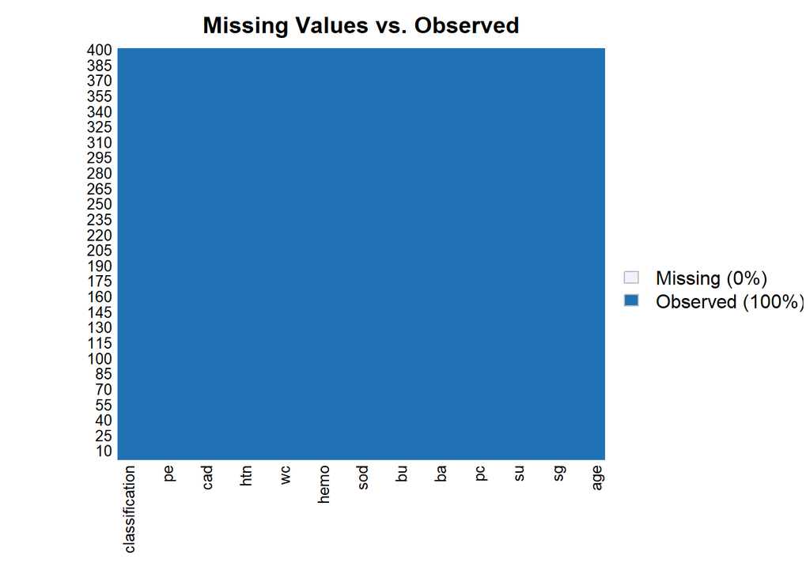

```r
library(Amelia)
missmap(data1, main = "Missing Values vs. Observed")
```

# Visualizing all the variables in the dataset # Visualizing dependent variables

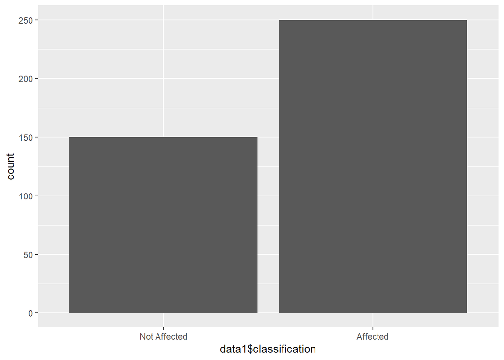

```r
library(ggplot2)
#Analysing Classification dependent variable
ggplot(data1, aes(data1$classification))+geom_bar()
```

# Below we shall visualize the independent variable

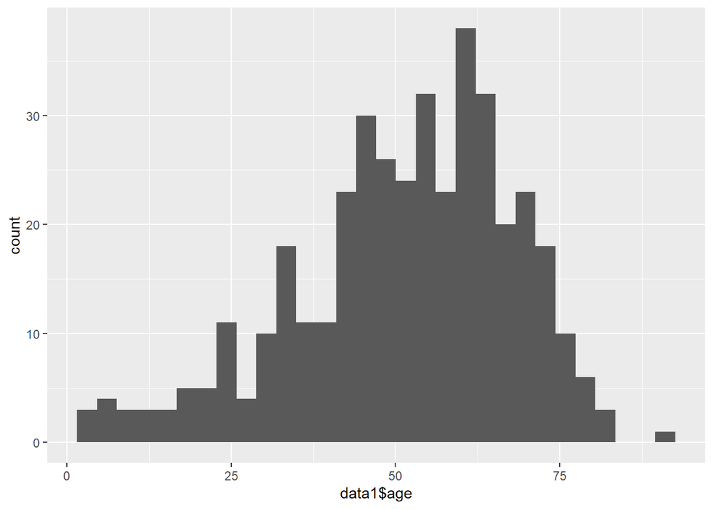

```r
library(ggplot2)

#Analysing age variable
ggplot(data1, aes(data1$age))+geom_histogram()
```

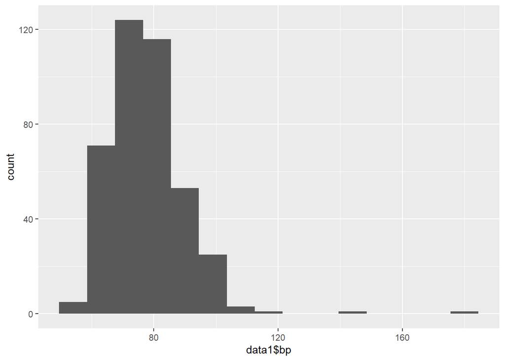

```r
#Analysing Blood pressure variable
ggplot(data1, aes(data1$bp))+geom_histogram(binwidth = 9)
```

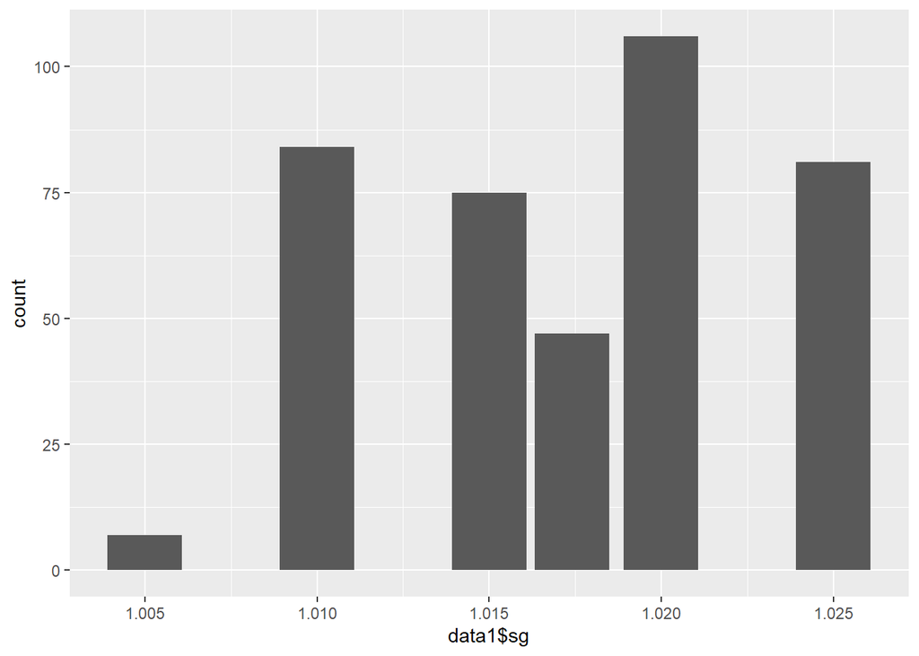

```r
# Analysing Specific gravity variable
ggplot(data1, aes(data1$sg))+geom_bar()
```

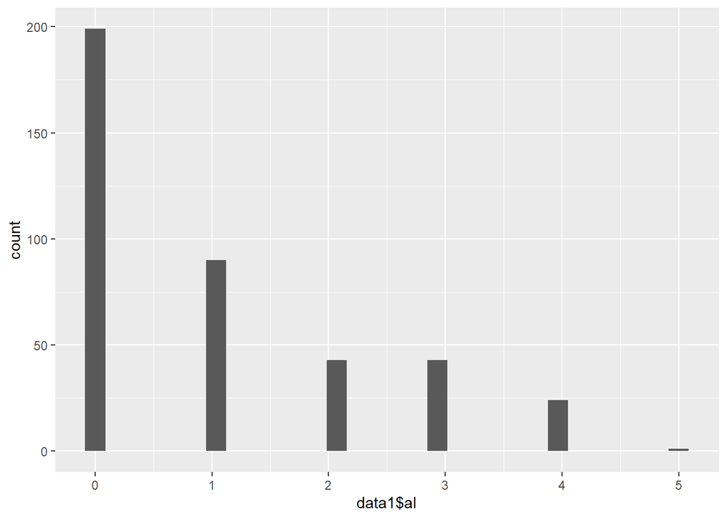

```r
# Analysing Albumin variable
ggplot(data1, aes(data1$al))+geom_histogram()
```

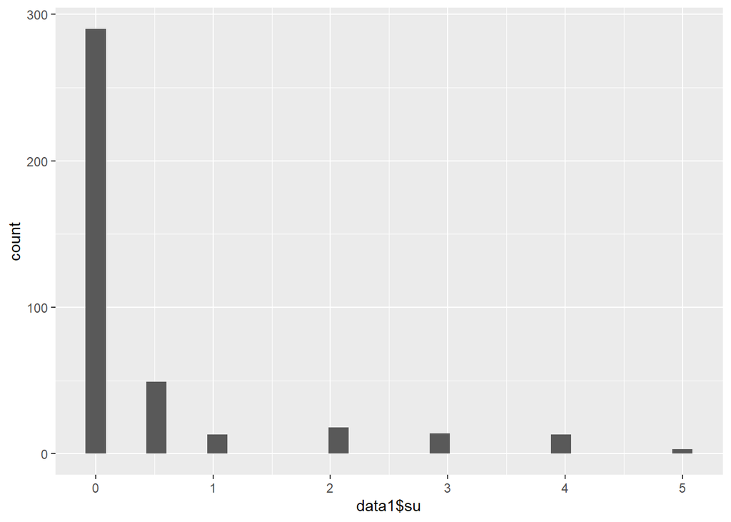

```r
# Analysing Sugar variable
ggplot(data1, aes(data1$su))+geom_histogram()
```

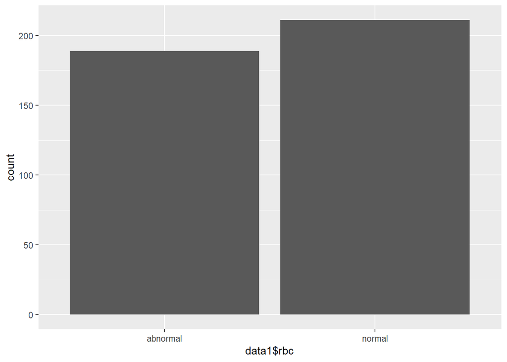

```r
# Analysing Red blood cells variable
ggplot(data1, aes(data1$rbc))+geom_bar()
```

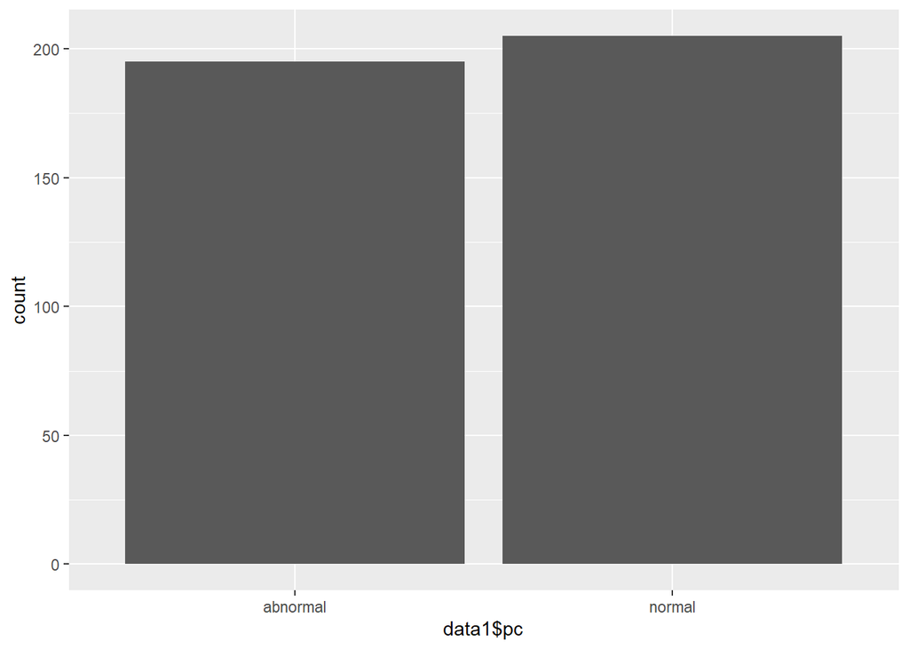

```r
# Analysing Pus cells variable
ggplot(data1, aes(data1$pc))+geom_bar()
```

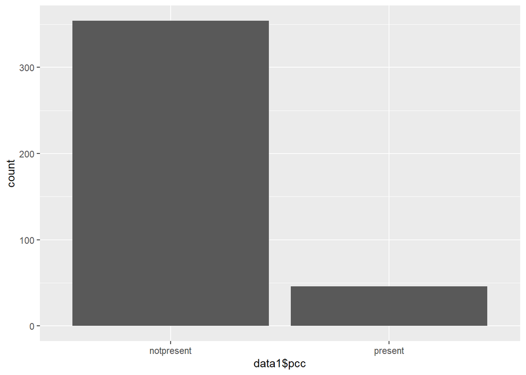

```r
# Analysing Pus cells clumps variable
ggplot(data1, aes(data1$pcc))+geom_bar()
```

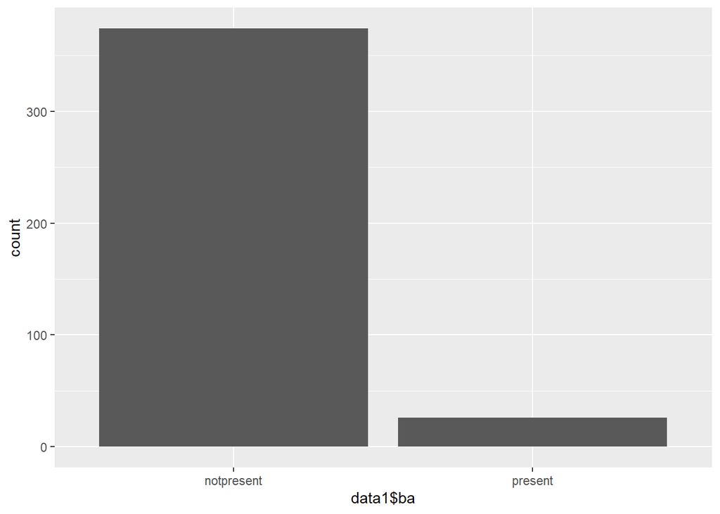

```r
# Analysing Bacteria variable
ggplot(data1, aes(data1$ba))+geom_bar()
```

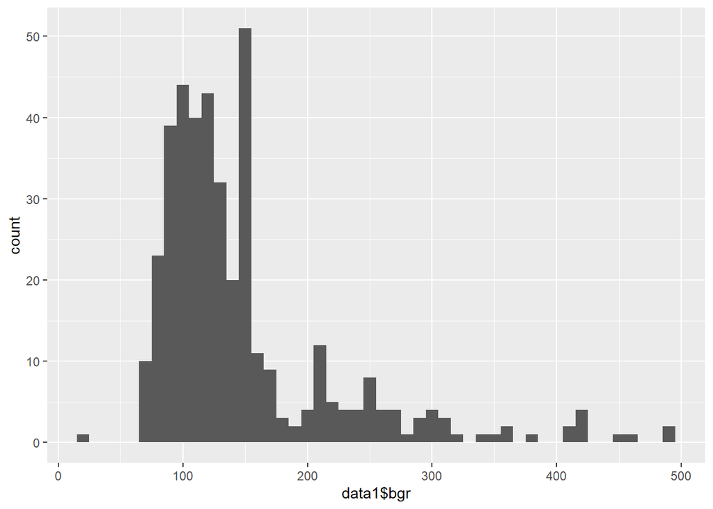

```r
# Analysing Blood Glucose random variable
ggplot(data1, aes(data1$bgr))+geom_histogram(binwidth = 10)
```

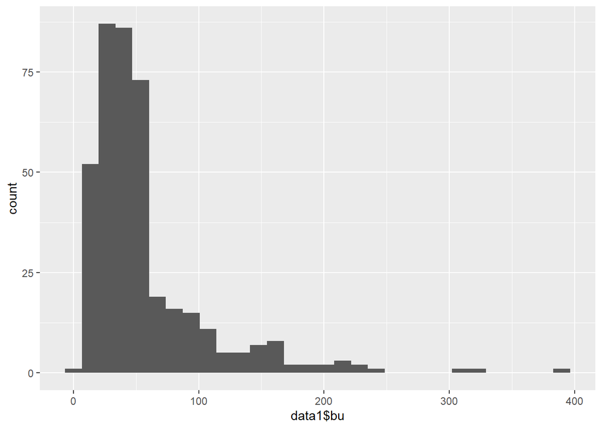

```r
# Analysing Blood Urea variable
ggplot(data1, aes(data1$bu))+geom_histogram()
```

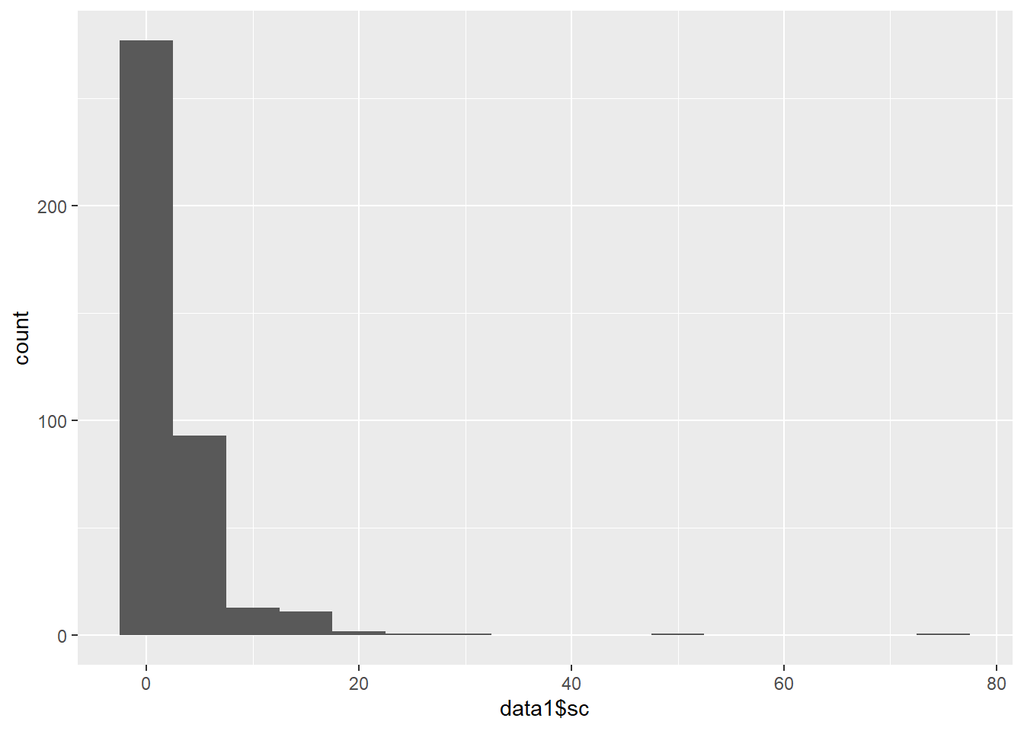

```r
# Analysing Serum Creatinine variable
ggplot(data1, aes(data1$sc))+geom_histogram(binwidth = 5)
```

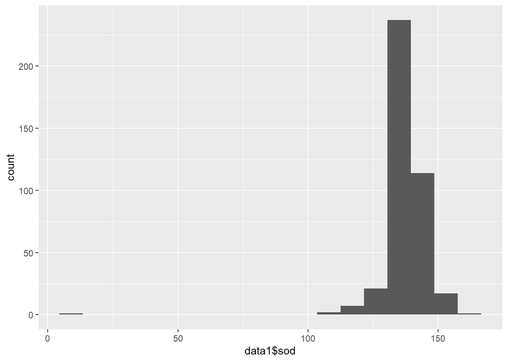

```r
# Analysing Sodium variable
ggplot(data1, aes(data1$sod))+geom_histogram(binwidth = 9)
```

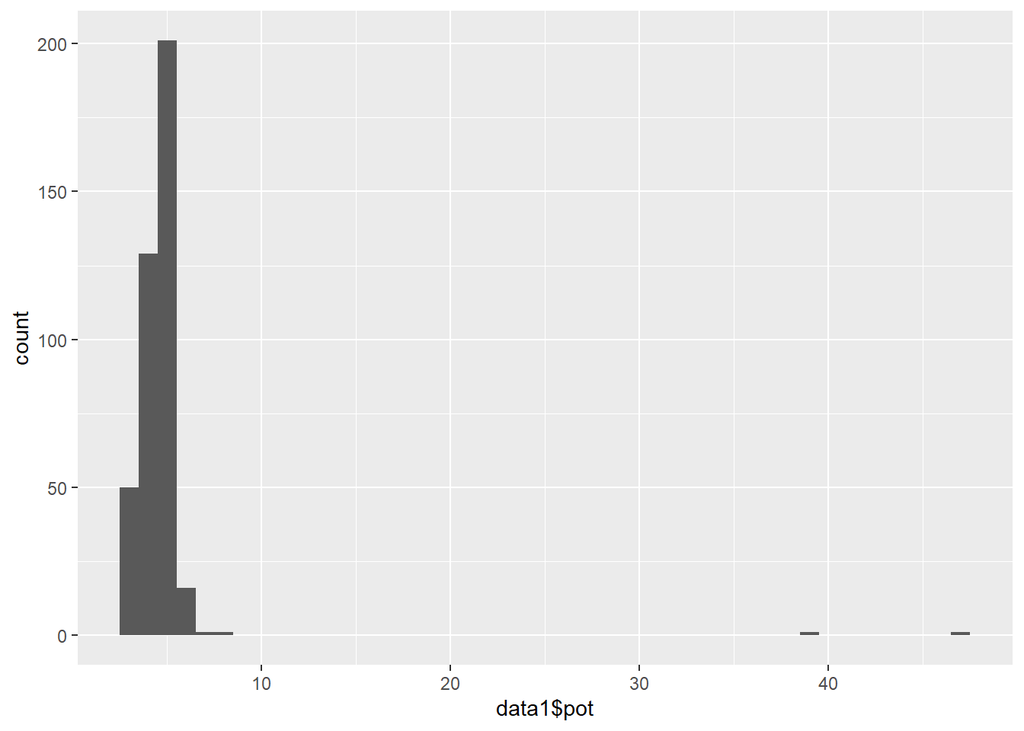

```r
# Analysing Potassium variable
ggplot(data1, aes(data1$pot))+geom_histogram(binwidth = 1)
```

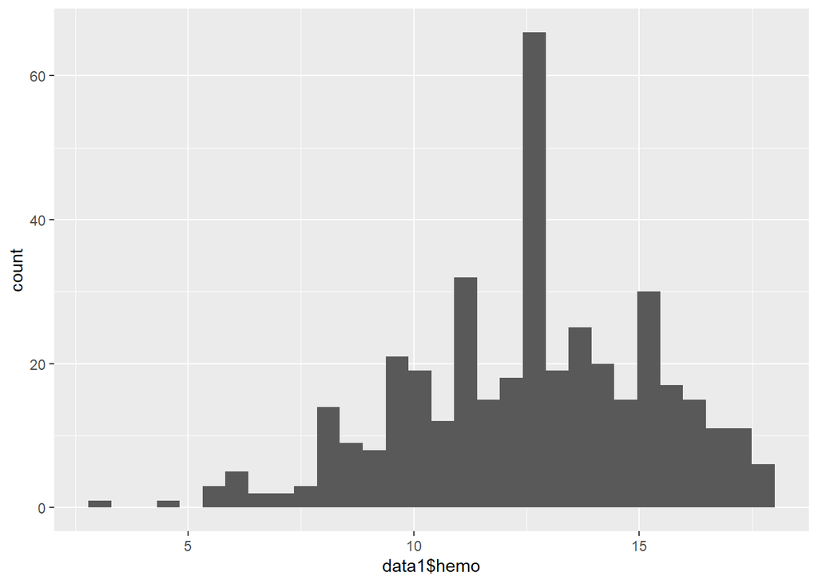

```r
# Analysing Hemoglobin variable
ggplot(data1, aes(data1$hemo))+geom_histogram()
```

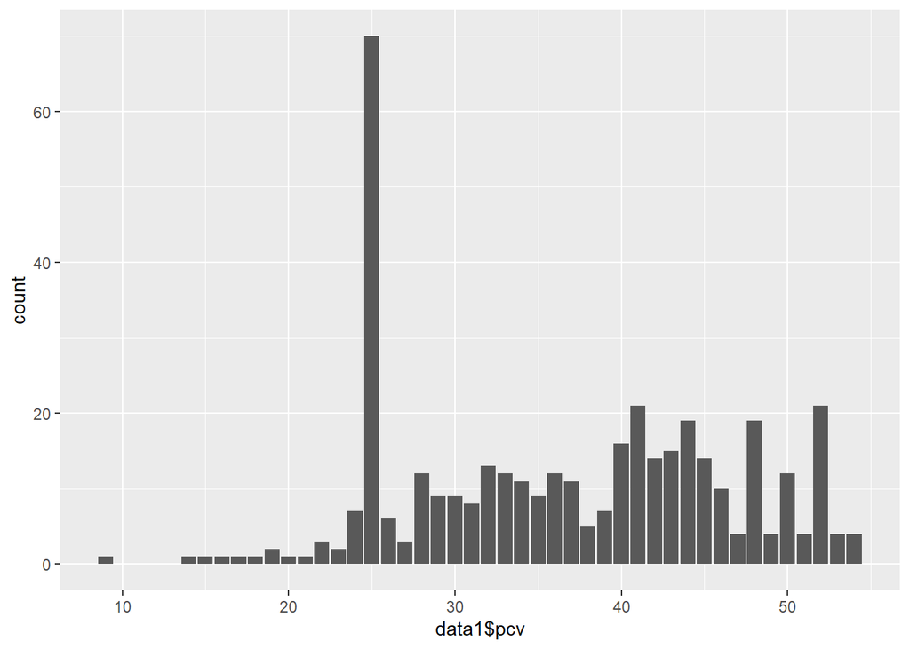

```r
# Analysing Packed cell volume variable
ggplot(data1, aes(data1$pcv))+geom_bar()
```

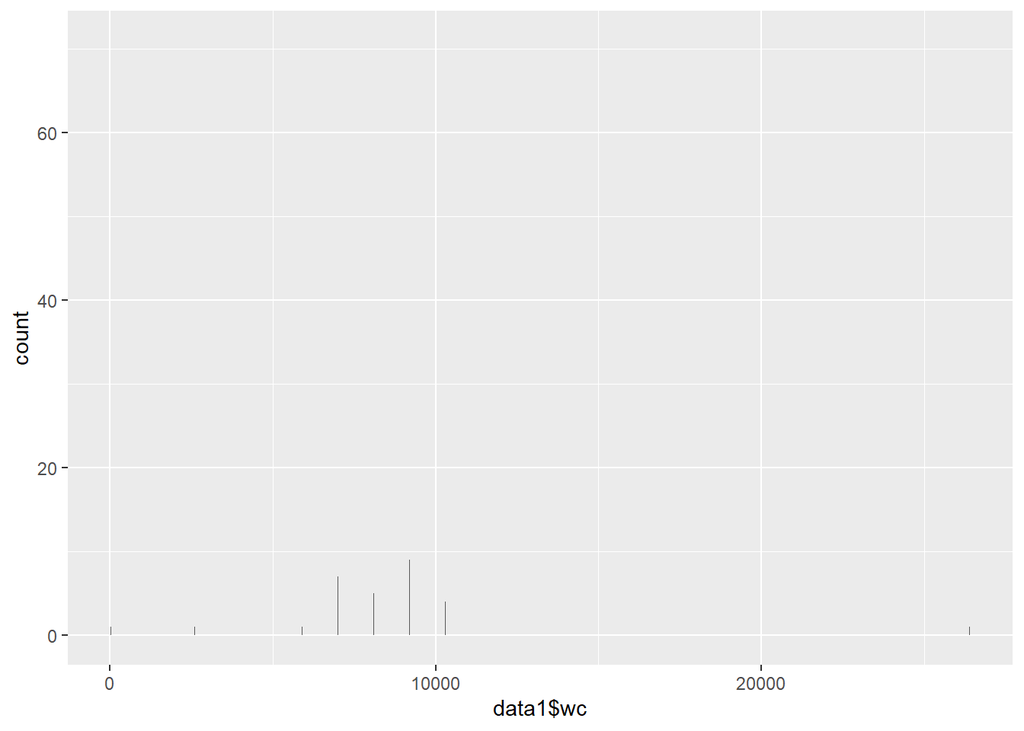

```r
# Analysing White blood cells count variable
ggplot(data1, aes(data1$wc))+geom_bar()
```

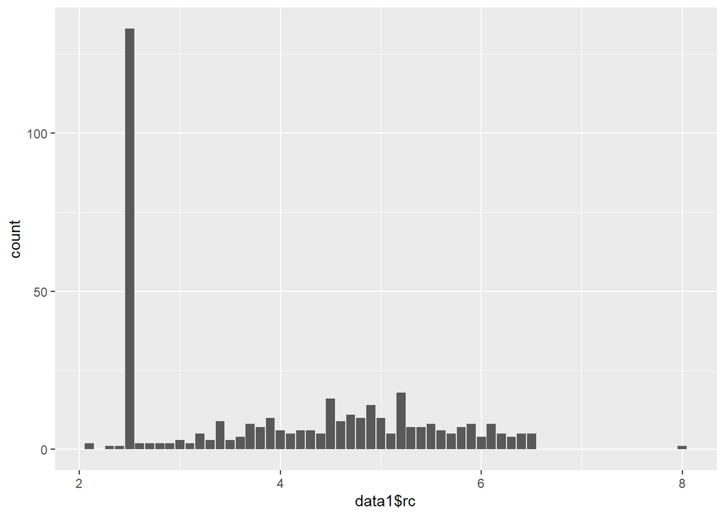

```r
# Analysing Red Blood cells count variable
ggplot(data1, aes(data1$rc))+geom_bar()
```

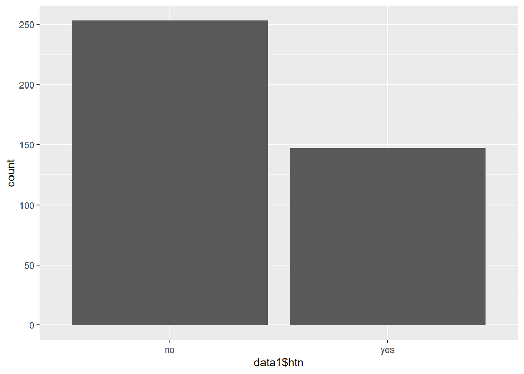

```r
# Analysing Hypertension variable
ggplot(data1, aes(data1$htn))+geom_bar()
```

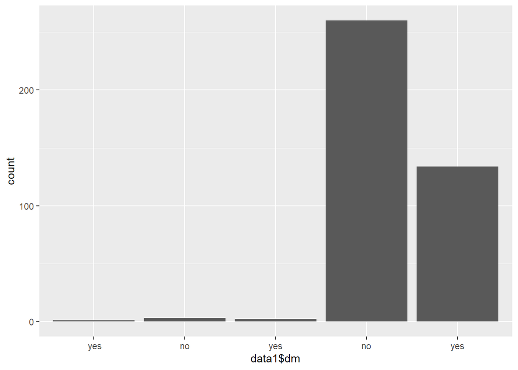

```r
# Analysing Diabetes Mellitus variable
ggplot(data1, aes(data1$dm))+geom_bar()
```

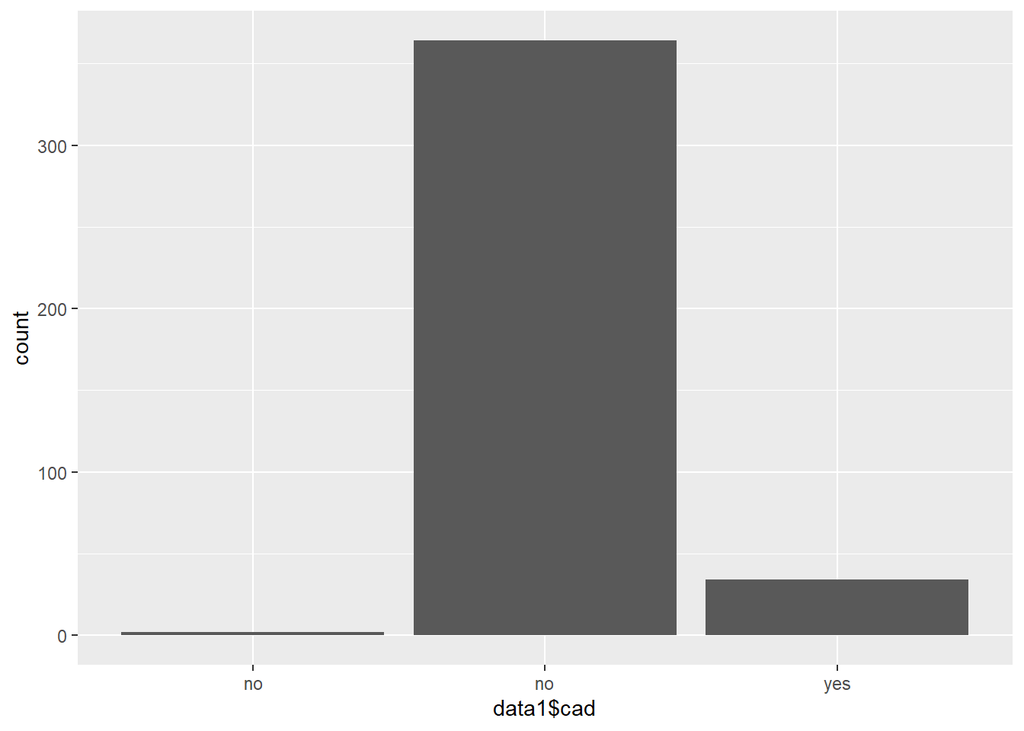

```r
# Analysing Coronary Artery disease variable
ggplot(data1, aes(data1$cad))+geom_bar()
```

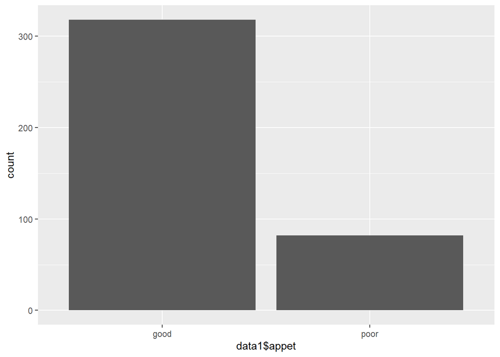

```r
# Analysing Appetite variable
ggplot(data1, aes(data1$appet))+geom_bar()
```

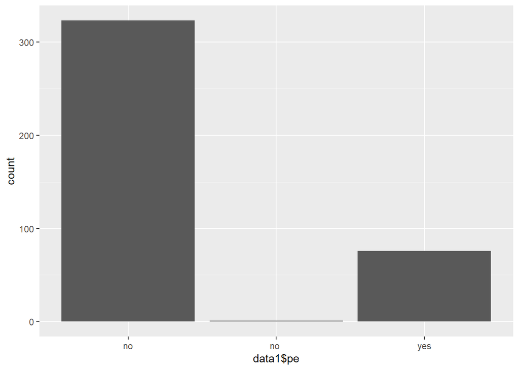

```r
# Analysing Pedal Edema variable
ggplot(data1, aes(data1$pe))+geom_bar()
```

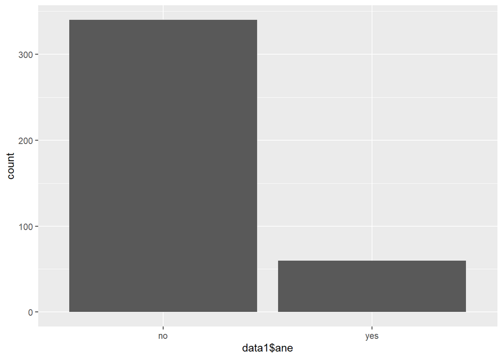

```r
# Analysing Anemia variable
ggplot(data1, aes(data1$ane))+geom_bar()
```

# Problem statement - Building a Logistic Regression model on dependent variable Classification (classifying between chronic kidney disease patient and non chronic kidney disease patient) and 24 independent variable age, blood Urea, Specific gravity, Albumin, Sugar, Red blood cells, Pus cells, Pus cells clumps, Bacteria, Blood Glucose random, Blood Urea, Serum Creatinine, sodium, Potassium, hemoglobin, Packed cell volume, White blood cells count, Red blood cells count, Hypertension, Diabetes Mellitus, Coronary Arteey disease, Appetite, Pedal Edema, Anemia and esstimating their relationship

# Here we are selecting the variables according to the problem statement

# Dividing the data into train and test data format by keeping 70% as split ratio

```r
library(caTools)
set.seed(100)
split1 = sample.split(data1$classification, SplitRatio = 0.70)

datatrain = subset(data1, split1 == TRUE)
datatest = subset(data1, split1 == FALSE)

dim(datatrain)
```

```
## [1] 280  25
```

```r
dim(datatest)
```

```
## [1] 120  25
```

# Below we are building Logistic regression between the dependent variable Classification and all other independent variables in the dataset

# From the below output we can see that there is a greate difference between Null deviance and Residual deviance indicating the model is good model

# We also see that the model has Lower AIC value specifing the goodness of the model

# The model build is 96% accurate in predicting or classifying between Chronic kidney disease Effected and Not Effected patients

# The value of Kappa 0.92 indicates that the model is almost perfect model

```r
library(blorr)
library(ISLR)
library(caret)
lreg1 = train(classification~.,
              method = "glm",
              family = "binomial",
              data = datatrain)
lreg1
```

```
## Generalized Linear Model
##
## 280 samples
##  24 predictor
##   2 classes: 'Not Affected', 'Affected'
##
## No pre-processing
## Resampling: Bootstrapped (25 reps)
## Summary of sample sizes: 280, 280, 280, 280, 280, 280, ...
## Resampling results:
##
##   Accuracy   Kappa
##   0.9603361  0.917859
```

```r
summary(lreg1)
```

```
##
## Call:
## NULL
##
## Deviance Residuals:
##        Min          1Q      Median          3Q         Max
## -3.839e-05  -2.100e-08   2.100e-08   2.100e-08   4.839e-05
##
## Coefficients:
##               Estimate Std. Error z value Pr(>|z|)
## (Intercept)  3.795e+03  7.991e+06       0        1
## age         -5.825e-01  1.274e+03       0        1
## bp           4.577e-01  2.673e+03       0        1
## sg          -3.446e+03  7.587e+06       0        1
## al           1.094e+01  3.712e+04       0        1
## su           7.320e+00  3.650e+04       0        1
## rbcnormal   -7.009e+00  6.971e+04       0        1
## pcnormal    -1.066e+01  5.524e+04       0        1
## pccpresent   7.291e+00  1.342e+05       0        1
## bapresent   -1.311e+01  1.247e+05       0        1
## bgr          1.269e-02  8.655e+02       0        1
## bu          -2.696e-01  1.907e+03       0        1
## sc           5.341e+00  2.908e+04       0        1
## sod         -1.407e+00  5.776e+03       0        1
## pot         -2.010e+00  1.547e+04       0        1
## hemo        -4.990e+00  2.445e+04       0        1
## pcv         -6.977e-01  1.782e+03       0        1
## wc           1.616e-03  6.399e+00       0        1
## rc          -5.679e+00  3.131e+04       0        1
## htnyes       2.442e+01  7.900e+04       0        1
## `dm\\tno`    1.336e+01  4.049e+05       0        1
## `dm\\tyes`  -1.726e+01  4.389e+05       0        1
## dmno         4.405e+00  3.707e+05       0        1
## dmyes        5.282e+01  3.748e+05       0        1
## cadno        5.308e+00  2.344e+05       0        1
## cadyes      -9.518e+00  2.836e+05       0        1
## appetpoor   -3.931e+00  9.710e+04       0        1
## `peno `      3.372e+01  3.626e+05       0        1
## peyes        2.167e+01  1.018e+05       0        1
## aneyes       1.789e+01  7.645e+04       0        1
##
## (Dispersion parameter for binomial family taken to be 1)
##
##     Null deviance: 3.7048e+02  on 279  degrees of freedom
## Residual deviance: 1.5856e-08  on 250  degrees of freedom
## AIC: 60
##
## Number of Fisher Scoring iterations: 25
```

```r
summary(lreg1$finalModel)
```

```
##
## Call:
## NULL
##
## Deviance Residuals:
##        Min          1Q      Median          3Q         Max
## -3.839e-05  -2.100e-08   2.100e-08   2.100e-08   4.839e-05
##
## Coefficients:
##               Estimate Std. Error z value Pr(>|z|)
## (Intercept)  3.795e+03  7.991e+06       0        1
## age         -5.825e-01  1.274e+03       0        1
## bp           4.577e-01  2.673e+03       0        1
## sg          -3.446e+03  7.587e+06       0        1
## al           1.094e+01  3.712e+04       0        1
## su           7.320e+00  3.650e+04       0        1
## rbcnormal   -7.009e+00  6.971e+04       0        1
## pcnormal    -1.066e+01  5.524e+04       0        1
## pccpresent   7.291e+00  1.342e+05       0        1
## bapresent   -1.311e+01  1.247e+05       0        1
## bgr          1.269e-02  8.655e+02       0        1
## bu          -2.696e-01  1.907e+03       0        1
## sc           5.341e+00  2.908e+04       0        1
## sod         -1.407e+00  5.776e+03       0        1
## pot         -2.010e+00  1.547e+04       0        1
## hemo        -4.990e+00  2.445e+04       0        1
## pcv         -6.977e-01  1.782e+03       0        1
## wc           1.616e-03  6.399e+00       0        1
## rc          -5.679e+00  3.131e+04       0        1
## htnyes       2.442e+01  7.900e+04       0        1
## `dm\\tno`    1.336e+01  4.049e+05       0        1
## `dm\\tyes`  -1.726e+01  4.389e+05       0        1
## dmno         4.405e+00  3.707e+05       0        1
## dmyes        5.282e+01  3.748e+05       0        1
## cadno        5.308e+00  2.344e+05       0        1
## cadyes      -9.518e+00  2.836e+05       0        1
## appetpoor   -3.931e+00  9.710e+04       0        1
## `peno `      3.372e+01  3.626e+05       0        1
## peyes        2.167e+01  1.018e+05       0        1
## aneyes       1.789e+01  7.645e+04       0        1
##
## (Dispersion parameter for binomial family taken to be 1)
##
##     Null deviance: 3.7048e+02  on 279  degrees of freedom
## Residual deviance: 1.5856e-08  on 250  degrees of freedom
## AIC: 60
##
## Number of Fisher Scoring iterations: 25
```

# before going to final model we need to check model fit

# The below output shows the likelihood ratio as 370 specifying the goodness of fit for the model

# As the MacFadden’s R2 is 1 which specifies that the model is good model for predicting or classifying between Chronic kidney disease patient and non chronic kidney disease patient

# Here we can also observe that the model has low AIC value that is 60

```r
library(blorr)
library(Rcpp)

blr_model_fit_stats(lreg1$finalModel)
```

```
##                                   Model Fit Statistics
## -----------------------------------------------------------------------------------------
## Log-Lik Intercept Only:          -185.238    Log-Lik Full Model:                    0.000
## Deviance(250):                      0.000    LR(29):                              370.475
##                                              Prob > LR:                             0.000
## MCFadden's R2                       1.000    McFadden's Adj R2:                     0.838
## ML (Cox-Snell) R2:                  0.734    Cragg-Uhler(Nagelkerke) R2:            1.000
## McKelvey & Zavoina's R2:            1.000    Efron's R2:                            1.000
## Count R2:                           1.000    Adj Count R2:                          1.000
## BIC:                              169.044    AIC:                                  60.000
## -----------------------------------------------------------------------------------------
```

# for further analysis we use hosmer lemeshow test

# null hypothesis: model is good fit: resulting accepting the model

# Alternate hypothesis: model is not good fit

# As here from the output the p-value is greater that 0.05 resulting in accepting the null hypothesis resulting that the model is good fit model

```r
blr_test_hosmer_lemeshow(lreg1$finalModel)
```

```
##            Partition for the Hosmer & Lemeshow Test
## --------------------------------------------------------------
##                         def = 1                 def = 0
## Group    Total    Observed    Expected    Observed    Expected
## --------------------------------------------------------------
##   1       88         0          0.00         88        88.00
##   4       24         7          7.00         17        17.00
##   5       168       168        168.00        0          0.00
##  NA       NA         NA          NA          NA          NA
##  NA       NA         NA          NA          NA          NA
##  NA       NA         NA          NA          NA          NA
##  NA       NA         NA          NA          NA          NA
##  NA       NA         NA          NA          NA          NA
##  NA       NA         NA          NA          NA          NA
##  NA       NA         NA          NA          NA          NA
## --------------------------------------------------------------
##
##      Goodness of Fit Test
## ------------------------------
## Chi-Square    DF    Pr > ChiSq
## ------------------------------
##   0.0000      8       1.0000
## ------------------------------
```

# Building a confusion matrix

# Here from the below output we can see that the model has high sensitivity and high specificity

# The model also has high Accuracy in predicting/classifying the chronic kidney disease patients

```r
blr_confusion_matrix(lreg1$finalModel, cutoff = 0.5)
```

```
## Confusion Matrix and Statistics
##
##           Reference
## Prediction Not Affected Affected
##          0          105        0
##          1            0      175
##
##
##                 Accuracy : 1.0000
##      No Information Rate : 0.3750
##
##                    Kappa : 1.0000
##
## McNemars's Test P-Value  : NaN
##
##              Sensitivity : 1.0000
##              Specificity : 1.0000
##           Pos Pred Value : 1.0000
##           Neg Pred Value : 1.0000
##               Prevalence : 0.6250
##           Detection Rate : 0.6250
##     Detection Prevalence : 0.6250
##        Balanced Accuracy : 1.0000
##                Precision : 1.0000
##                   Recall : 1.0000
##
##         'Positive' Class : 1
```

# Here below we will be finding the fitted values of the coefficients

```r
lreg1$finalModel$fitted.values
```

[output not shown]

[output cut: 39 more lines]

[output not shown]

# Here below we are building predict function and comparing it with test data varibales

# Here below we are building Confusion Matrix for getting predicted accuracy on test data

# The output of this shows that it has

# high Accuracy (95%), high Kappa value (89%), high Sensitivity (100%), high Specificity (92%) in predicting/classifying the chronic kidney disease patients

```r
library(blorr)
predict1 = predict(lreg1, datatest)
predict1
```

```
##   [1] Affected     Affected     Affected     Affected     Affected
##   [6] Affected     Affected     Affected     Affected     Affected
##  [11] Affected     Affected     Affected     Affected     Affected
##  [16] Affected     Affected     Affected     Affected     Affected
##  [21] Affected     Affected     Affected     Affected     Not Affected
##  [26] Affected     Affected     Affected     Affected     Affected
##  [31] Affected     Affected     Affected     Affected     Not Affected
##  [36] Affected     Affected     Affected     Affected     Affected
##  [41] Affected     Affected     Affected     Affected     Affected
##  [46] Not Affected Affected     Affected     Not Affected Affected
##  [51] Affected     Affected     Not Affected Affected     Affected
##  [56] Not Affected Affected     Affected     Affected     Affected
##  [61] Affected     Affected     Affected     Affected     Affected
##  [66] Affected     Affected     Affected     Affected     Affected
##  [71] Affected     Affected     Affected     Affected     Affected
##  [76] Not Affected Not Affected Not Affected Not Affected Not Affected
##  [81] Not Affected Not Affected Not Affected Not Affected Not Affected
##  [86] Not Affected Not Affected Not Affected Not Affected Not Affected
##  [91] Not Affected Not Affected Not Affected Not Affected Not Affected
##  [96] Not Affected Not Affected Not Affected Not Affected Not Affected
## [101] Not Affected Not Affected Not Affected Not Affected Not Affected
## [106] Not Affected Not Affected Not Affected Not Affected Not Affected
## [111] Not Affected Not Affected Not Affected Not Affected Not Affected
## [116] Not Affected Not Affected Not Affected Not Affected Not Affected
## Levels: Not Affected Affected
```

```r
confusionMatrix(predict1, datatest$classification)
```

```
## Confusion Matrix and Statistics
##
##               Reference
## Prediction     Not Affected Affected
##   Not Affected           45        6
##   Affected                0       69
##
##                Accuracy : 0.95
##                  95% CI : (0.8943, 0.9814)
##     No Information Rate : 0.625
##     P-Value [Acc > NIR] : < 2e-16
##
##                   Kappa : 0.8961
##
##  Mcnemar's Test P-Value : 0.04123
##
##             Sensitivity : 1.0000
##             Specificity : 0.9200
##          Pos Pred Value : 0.8824
##          Neg Pred Value : 1.0000
##              Prevalence : 0.3750
##          Detection Rate : 0.3750
##    Detection Prevalence : 0.4250
##       Balanced Accuracy : 0.9600
##
##        'Positive' Class : Not Affected
##
```

# Building an ROC curve for the dependent variable (classification)

# Here the ROC Curve specifies the model fit indices

# From the below graph output we can say that the independent variables has effect in dependent variable and the model if good fit model

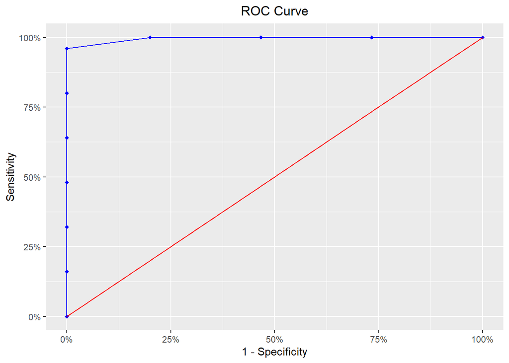

```r
gaintable = blr_gains_table(lreg1$finalModel)
blr_roc_curve(gaintable)
```

# Below we will perform Step wise AIC in bith directions (that is forward direction and backward direction)

# from the output we are rounding off to only six varibales those are Hemoglobin, Specific gravity, Diabetes Mellitus, Albumin, Pedal Edema, Packed cell volume that has effect on dependent variable classification

```r
library(blorr)

lregboth = blr_step_aic_both(lreg1$finalModel, details = TRUE)
```

```
## Stepwise Selection Method
## -------------------------
##
## Candidate Terms:
##
## 1 . age
## 2 . bp
## 3 . sg
## 4 . al
## 5 . su
## 6 . rbcnormal
## 7 . pcnormal
## 8 . pccpresent
## 9 . bapresent
## 10 . bgr
```

[output cut: 22 more lines]

```
##                 Enter New Variables
## --------------------------------------------------
## Variable      DF      AIC        BIC      Deviance
## --------------------------------------------------
## hemo           1    145.730    153.000     141.730
## pcv            1    168.637    175.906     164.637
## rc             1    178.910    186.180     174.910
## sg             1    183.285    190.554     179.285
## al             1    183.643    190.913     179.643
## sc             1    216.893    224.162     212.893
## htnyes         1    235.854    243.124     231.854
## dmno           1    243.185    250.455     239.185
## dmyes          1    253.694    260.963     249.694
## bgr            1    294.064    301.334     290.064
## sod            1    295.898    303.167     291.898
## bu             1    302.404    309.674     298.404
## su             1    305.838    313.108     301.838
## appetpoor      1    305.919    313.188     301.919
## peyes          1    316.169    323.438     312.169
## aneyes         1    327.115    334.384     323.115
## bp             1    345.494    352.764     341.494
## cadno          1    348.458    355.728     344.458
## cadyes         1    350.581    357.850     346.581
## pccpresent     1    355.407    362.676     351.407
## wc             1    361.239    368.508     357.239
## age            1    361.709    368.979     357.709
## pot            1    369.634    376.904     365.634
## `dm\tno`      1    371.636    378.906     367.636
## bapresent      1    371.668    378.938     367.668
## `peno `        1    372.508    379.777     368.508
## `dm\tyes`     1    372.587    379.856     368.587
## rbcnormal      1    373.728    380.998     369.728
## pcnormal       1    374.131    381.401     370.131
## --------------------------------------------------
##
## - hemo added
##
##
##  Step 1 : AIC = 145.7304
##  .outcome ~ hemo
```

```
##                 Enter New Variables
## --------------------------------------------------
## Variable      DF      AIC        BIC      Deviance
## --------------------------------------------------
## sg             1     83.245     94.150      77.245
## dmno           1     85.096     96.000      79.096
## dmyes          1     95.155    106.060      89.155
## al             1     98.919    109.824      92.919
## htnyes         1    104.869    115.773      98.869
## bgr            1    107.530    118.435     101.530
## su             1    109.128    120.033     103.128
## sc             1    120.050    130.954     114.050
## rc             1    126.073    136.977     120.073
## sod            1    131.205    142.109     125.205
## pcv            1    131.341    142.246     125.341
## peyes          1    132.664    143.568     126.664
## appetpoor      1    135.461    146.366     129.461
## bp             1    139.272    150.176     133.272
## `dm\tno`      1    142.344    153.249     136.344
## wc             1    144.253    155.157     138.253
## cadno          1    144.482    155.386     138.482
## cadyes         1    144.534    155.438     138.534
## bu             1    144.705    155.609     138.705
## age            1    145.005    155.910     139.005
## aneyes         1    145.318    156.223     139.318
## pccpresent     1    146.940    157.844     140.940
## pot            1    146.977    157.881     140.977
## `dm\tyes`     1    147.039    157.943     141.039
## `peno `        1    147.172    158.076     141.172
## rbcnormal      1    147.542    158.447     141.542
## pcnormal       1    147.662    158.567     141.662
## bapresent      1    147.724    158.628     141.724
## --------------------------------------------------
##
## - sg added
##
##
##  Step 2 : AIC = 83.24527
##  .outcome ~ hemo + sg
##
##             Remove Existing Variables
## -------------------------------------------------
## Variable     DF      AIC        BIC      Deviance
## -------------------------------------------------
## sg            1    145.730    153.000     141.730
## hemo          1    183.285    190.554     179.285
## -------------------------------------------------
```

```
##                Enter New Variables
## ------------------------------------------------
## Variable      DF     AIC       BIC      Deviance
## ------------------------------------------------
## dmno           1    49.798    64.337      41.798
## dmyes          1    50.384    64.924      42.384
## bgr            1    59.375    73.914      51.375
## al             1    59.379    73.918      51.379
## htnyes         1    59.402    73.941      51.402
## su             1    66.336    80.876      58.336
## sc             1    67.634    82.173      59.634
## appetpoor      1    68.724    83.263      60.724
## peyes          1    70.664    85.203      62.664
## sod            1    70.817    85.356      62.817
## pcv            1    71.866    86.405      63.866
## rc             1    72.546    87.085      64.546
## cadno          1    76.372    90.911      68.372
## cadyes         1    76.372    90.911      68.372
## aneyes         1    80.966    95.506      72.966
## bp             1    81.333    95.872      73.333
## age            1    82.672    97.212      74.672
## bu             1    83.345    97.884      75.345
## wc             1    83.844    98.384      75.844
## bapresent      1    84.005    98.544      76.005
## rbcnormal      1    84.318    98.857      76.318
## pot            1    84.482    99.021      76.482
## `peno `        1    84.852    99.391      76.852
## pccpresent     1    84.883    99.422      76.883
## `dm\tno`      1    85.072    99.611      77.072
## pcnormal       1    85.146    99.685      77.146
## `dm\tyes`     1    85.242    99.781      77.242
## ------------------------------------------------
##
## - dmno added
##
##
##  Step 3 : AIC = 49.79802
##  .outcome ~ hemo + sg + dmno
```

```
##             Remove Existing Variables
## -------------------------------------------------
## Variable     DF      AIC        BIC      Deviance
## -------------------------------------------------
## dmno          1     83.245     94.150      77.245
## sg            1     85.096     96.000      79.096
## hemo          1    116.519    127.423     110.519
## -------------------------------------------------
```

[output not shown]

```
##                Enter New Variables
## ------------------------------------------------
## Variable      DF     AIC       BIC      Deviance
## ------------------------------------------------
## al             1    29.596    47.770      19.596
## peyes          1    30.722    48.896      20.722
## appetpoor      1    32.278    50.452      22.278
## bgr            1    41.151    59.325      31.151
## sc             1    41.704    59.878      31.704
## rc             1    44.696    62.869      34.696
## sod            1    45.352    63.526      35.352
## aneyes         1    45.646    63.820      35.646
## pcv            1    46.052    64.226      36.052
## su             1    46.123    64.297      36.123
## htnyes         1    48.463    66.637      38.463
## bu             1    51.194    69.368      41.194
## wc             1    51.273    69.447      41.273
## rbcnormal      1    51.346    69.520      41.346
## pcnormal       1    51.387    69.561      41.387
## bapresent      1    51.578    69.752      41.578
## `peno `        1    51.701    69.875      41.701
## pot            1    51.776    69.950      41.776
## cadno          1    51.791    69.965      41.791
## cadyes         1    51.791    69.965      41.791
## age            1    51.791    69.965      41.791
## bp             1    51.797    69.971      41.797
## pccpresent     1    51.798    69.972      41.798
## dmyes          1    51.798    69.972      41.798
## `dm\tno`      1    51.798    69.972      41.798
## `dm\tyes`     1    51.798    69.972      41.798
## ------------------------------------------------
##
## - al added
##
##
##  Step 4 : AIC = 29.59596
##  .outcome ~ hemo + sg + dmno + al
```

```
##            Remove Existing Variables
## -----------------------------------------------
## Variable     DF     AIC       BIC      Deviance
## -----------------------------------------------
## al            1    49.798    64.337      41.798
## sg            1    57.112    71.651      49.112
## dmno          1    59.379    73.918      51.379
## hemo          1    65.971    80.510      57.971
## -----------------------------------------------
```

[output not shown]

```
##                Enter New Variables
## ------------------------------------------------
## Variable      DF     AIC       BIC      Deviance
## ------------------------------------------------
## peyes          1    19.631    41.439       7.631
## sc             1    22.211    44.020      10.211
## pcv            1    23.613    45.421      11.613
## appetpoor      1    23.715    45.524      11.715
## bgr            1    25.071    46.879      13.071
## aneyes         1    25.902    47.710      13.902
## sod            1    28.174    49.983      16.174
## rc             1    28.345    50.154      16.345
## wc             1    29.375    51.184      17.375
## htnyes         1    29.888    51.697      17.888
## su             1    30.714    52.522      18.714
## bapresent      1    30.862    52.671      18.862
## age            1    30.926    52.735      18.926
## bp             1    31.231    53.040      19.231
## pccpresent     1    31.331    53.140      19.331
## rbcnormal      1    31.385    53.194      19.385
## pot            1    31.459    53.268      19.459
## bu             1    31.586    53.395      19.586
## `peno `        1    31.586    53.395      19.586
## pcnormal       1    31.593    53.402      19.593
## cadno          1    31.596    53.405      19.596
## cadyes         1    31.596    53.405      19.596
## dmyes          1    31.596    53.405      19.596
## `dm\tno`      1    31.596    53.405      19.596
## `dm\tyes`     1    31.596    53.405      19.596
## ------------------------------------------------
##
## - peyes added
##
##
##  Step 5 : AIC = 19.63066
##  .outcome ~ hemo + sg + dmno + al + peyes
```

```
##            Remove Existing Variables
## -----------------------------------------------
## Variable     DF     AIC       BIC      Deviance
## -----------------------------------------------
## peyes         1    29.596    47.770      19.596
## al            1    30.722    48.896      20.722
## hemo          1    44.582    62.756      34.582
## dmno          1    57.188    75.362      47.188
## sg            1    57.312    75.486      47.312
## -----------------------------------------------
```

```
##                Enter New Variables
## ------------------------------------------------
## Variable      DF     AIC       BIC      Deviance
## ------------------------------------------------
## pcv            1    14.000    39.444       0.000
## sod            1    14.000    39.444       0.000
## rc             1    14.000    39.444       0.000
## sc             1    14.000    39.444       0.000
## bgr            1    14.000    39.444       0.000
## htnyes         1    19.602    45.046       5.602
## wc             1    19.833    45.277       5.833
## bu             1    20.073    45.517       6.073
## pccpresent     1    20.183    45.627       6.183
## pot            1    20.643    46.087       6.643
## su             1    20.660    46.104       6.660
## age            1    21.121    46.564       7.121
## bp             1    21.425    46.868       7.425
## rbcnormal      1    21.521    46.964       7.521
## bapresent      1    21.530    46.973       7.530
## appetpoor      1    21.612    47.056       7.612
## pcnormal       1    21.629    47.073       7.629
## aneyes         1    21.631    47.074       7.631
## `peno `        1    21.631    47.074       7.631
## cadno          1    21.631    47.074       7.631
## cadyes         1    21.631    47.074       7.631
## dmyes          1    21.631    47.074       7.631
## `dm\tno`      1    21.631    47.074       7.631
## `dm\tyes`     1    21.631    47.074       7.631
## ------------------------------------------------
##
## - pcv added
##
##
##  Step 6 : AIC = 14
##  .outcome ~ hemo + sg + dmno + al + peyes + pcv
```

```
##            Remove Existing Variables
## -----------------------------------------------
## Variable     DF     AIC       BIC      Deviance
## -----------------------------------------------
## hemo          1    15.819    37.628       3.819
## pcv           1    19.631    41.439       7.631
## peyes         1    23.613    45.421      11.613
## al            1    31.056    52.865      19.056
## dmno          1    52.962    74.770      40.962
## sg            1    55.567    77.375      43.567
## -----------------------------------------------
```

```
##                Enter New Variables
## ------------------------------------------------
## Variable      DF     AIC       BIC      Deviance
## ------------------------------------------------
## sc             1    16.000    45.078       0.000
## sod            1    16.000    45.078       0.000
## age            1    16.000    45.078       0.000
## bp             1    16.000    45.078       0.000
## su             1    16.000    45.078       0.000
## cadyes         1    16.000    45.078       0.000
## cadno          1    16.000    45.078       0.000
## bgr            1    16.000    45.078       0.000
## pcnormal       1    16.000    45.078       0.000
## rbcnormal      1    16.000    45.078       0.000
## dmyes          1    16.000    45.078       0.000
## pot            1    16.000    45.078       0.000
## `dm\tyes`     1    16.000    45.078       0.000
## htnyes         1    16.000    45.078       0.000
## `dm\tno`      1    16.000    45.078       0.000
## appetpoor      1    16.000    45.078       0.000
## bapresent      1    16.000    45.078       0.000
## rc             1    16.000    45.078       0.000
## bu             1    16.000    45.078       0.000
## aneyes         1    16.000    45.078       0.000
## `peno `        1    16.000    45.078       0.000
## wc             1    16.000    45.078       0.000
## pccpresent     1    16.000    45.078       0.000
## ------------------------------------------------
##
##
## No more variables to be added or removed.
##
## Final Model Output
## ------------------
```

```
##                              Model Overview
## ------------------------------------------------------------------------
## Data Set    Resp Var    Obs.    Df. Model    Df. Residual    Convergence
## ------------------------------------------------------------------------
##   data      .outcome    280        279           273            FALSE
## ------------------------------------------------------------------------
##
##                     Response Summary
## --------------------------------------------------------
## Outcome        Frequency        Outcome        Frequency
## --------------------------------------------------------
##    0              105              1              175
## --------------------------------------------------------
##
##                      Maximum Likelihood Estimates
## -----------------------------------------------------------------------
##  Parameter     DF     Estimate        Std. Error    z value    Pr(>|z|)
## -----------------------------------------------------------------------
## (Intercept)    1     33584.8683     3551067.4859     0.0095      0.9925
##    hemo        1      -35.8112         7669.0238    -0.0047      0.9963
##     sg         1     -32156.4412    3403938.6120    -0.0094      0.9925
##    dmno        1      -254.0393       31181.8074    -0.0081      0.9935
##     al         1       52.7445        11018.6754     0.0048      0.9962
##    peyes       1      147.3204        30417.9188     0.0048      0.9961
##     pcv        1       -4.0286          740.3613    -0.0054      0.9957
## -----------------------------------------------------------------------
##
## Association of Predicted Probabilities and Observed Responses
## -------------------------------------------------------------
## % Concordant         1.0000         Somers' D        1.0000
## % Discordant         0.0000         Gamma            1.0000
## % Tied               0.0000         Tau-a            0.4704
## Pairs                18375          c                1.0000
## -------------------------------------------------------------
```

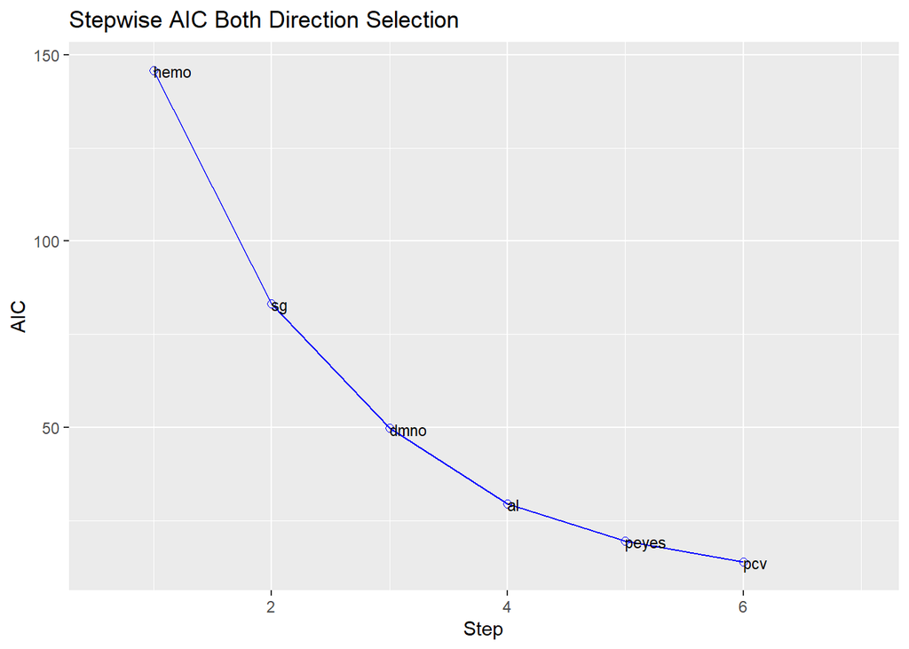

```r
plot(lregboth)
```